# R Notebook For John

# Load packages

```r
#install.packages("randomForest")
#install.packages("prediction")
#install.packages("class")
#install.packages("rpart")
#install.packages("olsrr")
#install.packages("broom")
#install.packages("modelr")
#install.packages("lme4")
#install.packages("lmerTest")
library(randomForest)
library(prediction)
library(class)
library(rpart)
library(olsrr) #John, load this package. It is way better for linear models. no need to separately get your confidence intervals!
library(tidyverse) #Also, tidyverse is an essentail. makes manipulating and reading data a easy (takes a while to download)
library(broom) #I forget what this is for! but use it anyways!
library(modelr) #For hierarchical modeling
library(lme4) #For Hierarchical modeling
library(lmerTest) # <- gives hierarchical modeling p-values (There is a reason it's NOT with lme4)
```

# Load data

`r`r X2017_All <- read_csv(Dataset.csv) # <- from tidyverse package

# Summary stats

`r`r #check for outliers and set filter for interquartiles for one model summary(X2017_All)

```
 Provider_Name       Week_Number      Day_Number      Charge_Day      Pred Value         Pred Z               CDZ             Charge_Week          CWZ
 Length:53783       Min.   : 1.00   Min.   :1.000   Min.   : 1.00   Min.   : 3.139   Min.   :-1.202059   Min.   :-1.528929   Min.   :  1.00   Min.   :-1.61915
 Class :character   1st Qu.: 6.00   1st Qu.:3.000   1st Qu.: 5.00   1st Qu.: 6.832   1st Qu.:-0.637769   1st Qu.:-0.917701   1st Qu.: 20.00   1st Qu.:-0.83369
 Mode  :character   Median :13.00   Median :4.000   Median :10.00   Median :10.524   Median :-0.073631   Median :-0.153667   Median : 38.00   Median :-0.08956
                    Mean   :18.63   Mean   :3.954   Mean   :11.01   Mean   :11.006   Mean   : 0.000001   Mean   : 0.000001   Mean   : 40.17   Mean   : 0.00000
                    3rd Qu.:31.00   3rd Qu.:5.000   3rd Qu.:16.00   3rd Qu.:14.864   3rd Qu.: 0.589641   3rd Qu.: 0.763174   3rd Qu.: 59.00   3rd Qu.: 0.77858
                    Max.   :53.00   Max.   :7.000   Max.   :72.00   Max.   :55.818   Max.   : 6.847584   Max.   : 9.320356   Max.   :133.00   Max.   : 3.83774
    Year_CD          Diff               All pos
 Min.   :2017   Min.   :-16.182346   Min.   : 0.000088
 1st Qu.:2017   1st Qu.: -1.336988   1st Qu.: 0.754380
 Median :2017   Median :  0.136645   Median : 1.410687
 Mean   :2017   Mean   :  0.000001   Mean   : 1.450781
 3rd Qu.:2018   3rd Qu.:  1.424091   3rd Qu.: 2.074771
 Max.   :2018   Max.   :  3.047649   Max.   :16.182346
```

# Charge_Day Histogram

`r`r ggplot(data = X2017_All, aes(x = Charge_Day)) + geom_histogram(binwidth = 1)

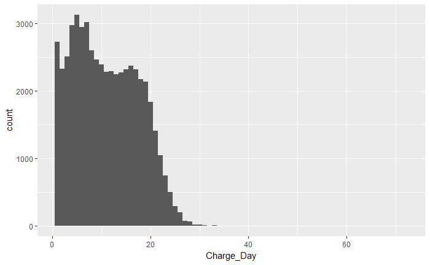

# Charge Week Histogram

`r`r ggplot(data = X2017_All, aes(x = Charge_Week)) + geom_histogram(binwidth = 1)

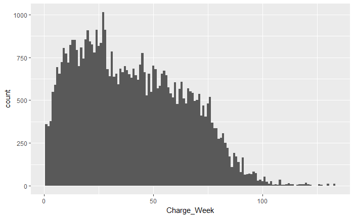

# Non-standardized model

We don’t need to standardize this because R does this for us! Keep it regular!

`r`r ####################################################################### ###Main Model, seems to be working best when I don’t remove outliers### ####################################################################### All<- lm(Charge_Day ~ Day_Number+ Week_Number + Charge_Week , data = X2017_All) ols_regress(All) # <- from olsrr

```
                        Model Summary
--------------------------------------------------------------
R                       0.741       RMSE                4.394
R-Squared               0.549       Coef. Var          39.924
Adj. R-Squared          0.549       MSE                19.306
Pred R-Squared          0.549       MAE                 3.291
--------------------------------------------------------------
 RMSE: Root Mean Square Error
 MSE: Mean Square Error
 MAE: Mean Absolute Error

                                    ANOVA
-----------------------------------------------------------------------------
                   Sum of
                  Squares           DF    Mean Square        F          Sig.
-----------------------------------------------------------------------------
Regression    1265074.672            3     421691.557    21842.192    0.0000
Residual      1038272.621        53779         19.306
Total         2303347.293        53782
-----------------------------------------------------------------------------

                                   Parameter Estimates
-----------------------------------------------------------------------------------------
      model      Beta    Std. Error    Std. Beta       t        Sig      lower     upper
-----------------------------------------------------------------------------------------
(Intercept)     3.473         0.068                  51.303    0.000     3.340     3.605
 Day_Number    -0.139         0.013       -0.030    -10.446    0.000    -0.165    -0.113
Week_Number     0.001         0.001        0.003      1.136    0.256    -0.001     0.004
Charge_Week     0.201         0.001        0.741    255.963    0.000     0.199     0.202
-----------------------------------------------------------------------------------------
```

`r`r #summary(All) #confint(All)

`r`r ####################################################################### ###Main Model, seems to be working best when I don’t remove outliers### ####################################################################### All<- lm(CDZ ~ Day_Number+ Week_Number + CWZ , data = X2017_All) ols_regress(All) # <- from olsrr

```
                            Model Summary
---------------------------------------------------------------------
R                       0.741       RMSE                       0.671
R-Squared               0.549       Coef. Var          117151664.643
Adj. R-Squared          0.549       MSE                        0.451
Pred R-Squared          0.549       MAE                        0.503
---------------------------------------------------------------------
 RMSE: Root Mean Square Error
 MSE: Mean Square Error
 MAE: Mean Absolute Error

                                   ANOVA
---------------------------------------------------------------------------
                 Sum of
                Squares           DF    Mean Square        F          Sig.
---------------------------------------------------------------------------
Regression    29539.403            3       9846.468    21842.192    0.0000
Residual      24243.591        53779          0.451
Total         53782.993        53782
---------------------------------------------------------------------------

                                   Parameter Estimates
-----------------------------------------------------------------------------------------
      model      Beta    Std. Error    Std. Beta       t        Sig      lower     upper
-----------------------------------------------------------------------------------------
(Intercept)     0.080         0.009                   8.617    0.000     0.062     0.098
 Day_Number    -0.021         0.002       -0.030    -10.446    0.000    -0.025    -0.017
Week_Number     0.000         0.000        0.003      1.136    0.256     0.000     0.001
        CWZ     0.741         0.003        0.741    255.963    0.000     0.736     0.747
-----------------------------------------------------------------------------------------
```

`r`r #summary(All) #confint(All)

`r`r ggplot(data = X2017_All, aes(x = CWZ, y = CDZ)) + geom_point() + geom_smooth(method = )

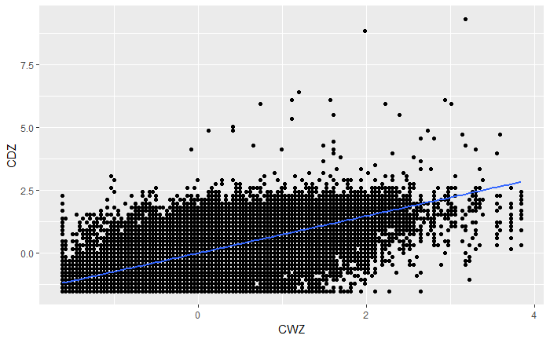

`r`r ggplot(data = X2017_All, aes(x = Charge_Week, y = Charge_Day)) + geom_point() + geom_smooth(method = )

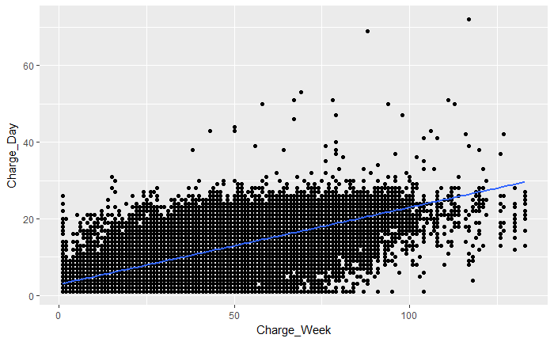